# DIH Analysis Complete

### 3.1.2 Sandwich Estimator

```r
#check the assumption of conditional independence

#First, need to create a lagged variable for the past OD deaths and proportion of deaths
main_analysis_data_with_lagged_deaths <- main_analysis_data %>%
  arrange(State, Time_Period_ID) %>%
  group_by(State) %>%
  mutate(lag_deaths = lag(imputed_deaths),
         lag_prop_death = lag(imputed_deaths/population),
         prop_death = imputed_deaths/population)

#Then fit model to see if OD deaths for state s at time t depends on the past

# Logistic Model
main_analysis_model_past_OD_logistic <- gam(cbind(round(imputed_deaths), round(num_alive))~ State +
                                              s(Time_Period_ID, bs = "cr", by = as.factor(Region)) +
                                              Naloxone_Pharmacy_Yes_Redefined +
                                              Naloxone_Pharmacy_No_Redefined +
                                              Medical_Marijuana_Redefined +
                                              Recreational_Marijuana_Redefined +
                                              GSL_Redefined +
                                              PDMP_Redefined +
                                              Medicaid_Expansion_Redefined +
                                              Intervention_Redefined +
                                              num_states_w_intervention +
                                              lag_prop_death,
                                            data = main_analysis_data_with_lagged_deaths, family = "binomial")
# stargazer(main_analysis_model_past_OD_logistic, type = "html")
summary(main_analysis_model_past_OD_logistic)
```

```
##
## Family: binomial
## Link function: logit
##
## Formula:
## cbind(round(imputed_deaths), round(num_alive)) ~ State + s(Time_Period_ID,
##     bs = "cr", by = as.factor(Region)) + Naloxone_Pharmacy_Yes_Redefined +
##     Naloxone_Pharmacy_No_Redefined + Medical_Marijuana_Redefined +
##     Recreational_Marijuana_Redefined + GSL_Redefined + PDMP_Redefined +
##     Medicaid_Expansion_Redefined + Intervention_Redefined + num_states_w_intervention +
##     lag_prop_death
##
## Parametric coefficients:
##                                    Estimate Std. Error  z value Pr(>|z|)
## (Intercept)                      -1.035e+01  5.907e-02 -175.214  < 2e-16 ***
## StateAlaska                       2.434e-01  2.775e-02    8.772  < 2e-16 ***
## StateArizona                      2.382e-01  1.405e-02   16.957  < 2e-16 ***
## StateArkansas                    -2.572e-01  1.981e-02  -12.985  < 2e-16 ***
## StateCalifornia                  -5.545e-02  1.348e-02   -4.112 3.92e-05 ***
## StateColorado                     1.222e-01  1.616e-02    7.560 4.02e-14 ***
## StateConnecticut                  1.511e-01  1.562e-02    9.676  < 2e-16 ***
## StateDelaware                     2.699e-01  2.256e-02   11.960  < 2e-16 ***
## StateFlorida                      1.927e-01  1.193e-02   16.157  < 2e-16 ***
## StateGeorgia                     -3.614e-02  1.340e-02   -2.696 0.007015 **
## StateHawaii                      -1.244e-01  2.575e-02   -4.830 1.36e-06 ***
## StateIdaho                       -1.253e-01  2.389e-02   -5.246 1.56e-07 ***
## StateIllinois                     3.477e-02  1.301e-02    2.671 0.007552 **
## StateIndiana                      4.958e-02  1.392e-02    3.561 0.000370 ***
## StateIowa                        -5.555e-01  2.160e-02  -25.715  < 2e-16 ***
## StateKansas                      -2.429e-01  1.952e-02  -12.446  < 2e-16 ***
## StateKentucky                     3.783e-01  1.440e-02   26.263  < 2e-16 ***
## StateLouisiana                    2.119e-01  1.435e-02   14.766  < 2e-16 ***
## StateMaine                        1.210e-01  2.160e-02    5.601 2.13e-08 ***
## StateMaryland                    -8.144e-01  1.980e-02  -41.136  < 2e-16 ***
## StateMassachusetts                1.197e-01  1.392e-02    8.598  < 2e-16 ***
## StateMichigan                     1.512e-02  1.361e-02    1.110 0.266796
## StateMinnesota                   -3.859e-01  1.773e-02  -21.766  < 2e-16 ***
## StateMississippi                 -6.290e-02  1.817e-02   -3.461 0.000538 ***
## StateMissouri                     1.362e-01  1.465e-02    9.296  < 2e-16 ***
## StateMontana                     -2.255e-01  2.970e-02   -7.594 3.10e-14 ***
```

[output cut: 33 more lines]

```
## lag_prop_death                    4.281e+03  6.823e+01   62.744  < 2e-16 ***
## ---
## Signif. codes:  0 '***' 0.001 '**' 0.01 '*' 0.05 '.' 0.1 ' ' 1
##
## Approximate significance of smooth terms:
##                                                edf Ref.df Chi.sq p-value
## s(Time_Period_ID):as.factor(Region)Midwest   8.899  8.997  557.6  <2e-16 ***
## s(Time_Period_ID):as.factor(Region)Northeast 8.965  9.000  932.2  <2e-16 ***
## s(Time_Period_ID):as.factor(Region)South     8.961  8.999 1161.5  <2e-16 ***
## s(Time_Period_ID):as.factor(Region)West      8.955  8.999  871.1  <2e-16 ***
## ---
## Signif. codes:  0 '***' 0.001 '**' 0.01 '*' 0.05 '.' 0.1 ' ' 1
##
## R-sq.(adj) =  0.927   Deviance explained = 92.5%
## UBRE =    6.5  Scale est. = 1         n = 1950
```

```r
# Linear Link Function
main_analysis_model_past_OD_lin_link <- gam(log(prop_death)~ State +
                                              s(Time_Period_ID, bs = "cr", by = as.factor(Region)) +
                                              Naloxone_Pharmacy_Yes_Redefined +
                                              Naloxone_Pharmacy_No_Redefined +
                                              Medical_Marijuana_Redefined +
                                              Recreational_Marijuana_Redefined +
                                              GSL_Redefined +
                                              PDMP_Redefined +
                                              Medicaid_Expansion_Redefined +
                                              Intervention_Redefined +
                                              num_states_w_intervention +
                                              lag_prop_death,
                                            data = main_analysis_data_with_lagged_deaths)
# stargazer(main_analysis_model_past_OD_lin_link, type = "html")
summary(main_analysis_model_past_OD_lin_link)
```

```
##
## Family: gaussian
## Link function: identity
##
## Formula:
## log(prop_death) ~ State + s(Time_Period_ID, bs = "cr", by = as.factor(Region)) +
##     Naloxone_Pharmacy_Yes_Redefined + Naloxone_Pharmacy_No_Redefined +
##     Medical_Marijuana_Redefined + Recreational_Marijuana_Redefined +
##     GSL_Redefined + PDMP_Redefined + Medicaid_Expansion_Redefined +
##     Intervention_Redefined + num_states_w_intervention + lag_prop_death
##
## Parametric coefficients:
##                                    Estimate Std. Error t value Pr(>|t|)
## (Intercept)                      -1.005e+01  2.001e-01 -50.222  < 2e-16 ***
## StateAlaska                       1.206e-01  6.791e-02   1.776 0.075863 .
## StateArizona                      1.857e-01  6.196e-02   2.997 0.002761 **
## StateArkansas                    -3.215e-01  6.145e-02  -5.232 1.86e-07 ***
## StateCalifornia                  -8.339e-02  6.812e-02  -1.224 0.221034
## StateColorado                     5.067e-02  6.795e-02   0.746 0.455977
## StateConnecticut                  1.098e-01  6.489e-02   1.693 0.090701 .
## StateDelaware                     7.884e-02  6.243e-02   1.263 0.206822
## StateFlorida                      2.064e-01  6.108e-02   3.380 0.000741 ***
## StateGeorgia                      3.975e-02  6.089e-02   0.653 0.513885
## StateHawaii                      -2.378e-01  6.722e-02  -3.537 0.000414 ***
## StateIdaho                       -8.448e-02  6.086e-02  -1.388 0.165270
## StateIllinois                     1.086e-01  6.177e-02   1.759 0.078821 .
## StateIndiana                      1.660e-02  6.054e-02   0.274 0.783981
## StateIowa                        -4.769e-01  6.156e-02  -7.747 1.53e-14 ***
## StateKansas                      -1.288e-01  6.038e-02  -2.133 0.033068 *
## StateKentucky                     3.314e-01  6.376e-02   5.197 2.24e-07 ***
## StateLouisiana                    2.151e-01  6.045e-02   3.558 0.000383 ***
## StateMaine                        4.786e-02  6.740e-02   0.710 0.477801
## StateMaryland                    -1.204e+00  6.418e-02 -18.759  < 2e-16 ***
## StateMassachusetts               -1.840e-01  6.168e-02  -2.983 0.002895 **
## StateMichigan                    -1.303e-02  6.237e-02  -0.209 0.834529
## StateMinnesota                   -4.124e-01  6.516e-02  -6.328 3.10e-10 ***
## StateMississippi                 -1.070e-02  6.016e-02  -0.178 0.858877
## StateMissouri                     1.255e-01  6.237e-02   2.013 0.044284 *
## StateMontana                     -2.426e-01  6.514e-02  -3.724 0.000202 ***
## StateNebraska                    -6.402e-01  6.232e-02 -10.274  < 2e-16 ***
```

[output cut: 32 more lines]

```
## lag_prop_death                    6.344e+03  3.332e+02  19.043  < 2e-16 ***
## ---
## Signif. codes:  0 '***' 0.001 '**' 0.01 '*' 0.05 '.' 0.1 ' ' 1
##
## Approximate significance of smooth terms:
##                                                edf Ref.df      F  p-value
## s(Time_Period_ID):as.factor(Region)Midwest   3.724  4.669 10.956  < 2e-16 ***
## s(Time_Period_ID):as.factor(Region)Northeast 8.555  8.941 10.765  < 2e-16 ***
## s(Time_Period_ID):as.factor(Region)South     4.251  5.288  7.296 1.10e-06 ***
## s(Time_Period_ID):as.factor(Region)West      6.260  7.406  4.825 2.24e-05 ***
## ---
## Signif. codes:  0 '***' 0.001 '**' 0.01 '*' 0.05 '.' 0.1 ' ' 1
##
## R-sq.(adj) =  0.865   Deviance explained =   87%
## GCV = 0.072604  Scale est. = 0.069521  n = 1950
```

```r
#here, we estimate the variance-covariance matrix through the sandwich estimator
#we create a function so that we don't have to keep writing the code:
#cov_data is such that rows are state-time combinations and columns are the different policy measures
#coef_values need to be in order of the columns of cov_data
#z_value is the z-value that corresponds to the CI. We default to 95% CI so we default to 1.96
#l is the number of parameters
#print_full_cov indicates whether to return the full variance-covariance matrix

compute_sd_and_CI <- function(cov_data, observed_y, coef_values, l, z_value = 1.96,
                              print_full_cov = FALSE){
  C_term <- middle_term <- matrix(0, nrow = ncol(cov_data), ncol = ncol(cov_data))
  for(i in 1:nrow(cov_data)){
    pst <- expit(t(as.matrix(cov_data[i,]))%*%coef_values)

    #compute the middle term
    middle_term <- middle_term + tcrossprod(as.matrix(cov_data[i,]))*
      as.numeric((observed_y[i] - pst)^2)

    #compute the C term
    C_term <- C_term + tcrossprod(as.matrix(cov_data[i,]))*as.numeric(pst*(1 - pst))
  }

  #compute C^{-1}
  inverse_C_term <- solve(C_term)

  #bias correcting term
  bias_correcting_term <- (nrow(cov_data)/(nrow(cov_data) - l))

  #compute the variance covarianc ematrix
  var_cov <- inverse_C_term%*%as.matrix(middle_term)%*%inverse_C_term*bias_correcting_term

  #we obtain the standard deviations by taking the square root of the diagonal of the variance-covariance matrix.
  sd_of_coefficients <- sqrt(diag(var_cov))

  #find the CI for the coefficients
  lb_coef <- coef_values - z_value*(sd_of_coefficients)
  ub_coef <- coef_values + z_value*(sd_of_coefficients)

  return_data_set <- data.frame(lb_coef, coef_values, ub_coef,
             exp_lb = exp(lb_coef), exp_coef = exp(coef_values),
             exp_ub = exp(ub_coef), sd_coef = sd_of_coefficients)


  #if print_full_cov == TRUE, return full variance covariance matrix
  if(print_full_cov){
    return(list(return_data_set = return_data_set, var_cov = var_cov))
  }else{
    return(return_data_set)
  }
}
```

```r
#compute the full dataset including basis functions
full_df_w_basis_functions <- as.matrix(data.frame(predict(main_analysis_model, type = "lpmatrix")))

main_analysis_data$prop_dead <- main_analysis_data$imputed_deaths/main_analysis_data$population
#estimate the 95% CI and SD
coefficient_values <- coef(main_analysis_model)
#type = "response" to get the estimated probabilities
main_analysis_sd_and_ci <- compute_sd_and_CI(full_df_w_basis_functions,
                                             (main_analysis_data$prop_dead),
                                             coefficient_values,
                                             l = ncol(full_df_w_basis_functions))
main_analysis_sd_and_ci
```

```
##                                                      lb_coef  coef_values
## (Intercept)                                    -10.308488114 -9.910683905
## StateAlaska                                      0.175491060  0.277124435
## StateArizona                                     0.242659853  0.314585049
## StateArkansas                                   -0.483594765 -0.390147951
## StateCalifornia                                 -0.240062495 -0.159081744
## StateColorado                                    0.013920239  0.096391872
## StateConnecticut                                 0.103893959  0.189169793
## StateDelaware                                    0.298370748  0.429695792
## StateFlorida                                     0.177995915  0.252764060
## StateGeorgia                                    -0.137537761 -0.070894080
## StateHawaii                                     -0.330792322 -0.226207450
## StateIdaho                                      -0.225274666 -0.136053870
## StateIllinois                                   -0.102045941 -0.015719511
## StateIndiana                                     0.015433807  0.087870098
## StateIowa                                       -0.826922134 -0.740259041
## StateKansas                                     -0.426599073 -0.328118789
## StateKentucky                                    0.566739133  0.641036674
## StateLouisiana                                   0.219305292  0.293912126
## StateMaine                                       0.045404482  0.145218784
## StateMaryland                                   -1.284828972 -1.066507716
## StateMassachusetts                               0.101763601  0.207593170
## StateMichigan                                   -0.092484322 -0.019359757
## StateMinnesota                                  -0.699339392 -0.618346548
## StateMississippi                                -0.183369135 -0.099561652
## StateMissouri                                    0.116307065  0.193755948
## StateMontana                                    -0.447969861 -0.359472606
## StateNebraska                                   -0.983575254 -0.882834150
## StateNevada                                      0.354543655  0.438995770
## StateNew Hampshire                               0.167471061  0.257357166
## StateNew Jersey                                  0.008150679  0.107244732
## StateNew Mexico                                  0.540540927  0.631025942
## StateNew York                                   -0.313880445 -0.238478067
## StateNorth Carolina                              0.110041144  0.176906773
## StateNorth Dakota                               -1.176710064 -1.052755943
## StateOhio                                        0.370150731  0.454809916
## StateOklahoma                                    0.283133277  0.385268538
## StateOregon                                     -0.279113919 -0.194288428
## StatePennsylvania                                0.362632623  0.435606947
## StateRhode Island                                0.110286001  0.237999011
```

[output cut: 329 more lines]

```
## s(Time_Period_ID):as.factor(Region)South.4     0.057993434
## s(Time_Period_ID):as.factor(Region)South.5     0.102571554
## s(Time_Period_ID):as.factor(Region)South.6     0.144610801
## s(Time_Period_ID):as.factor(Region)South.7     0.166393842
## s(Time_Period_ID):as.factor(Region)South.8     0.207494723
## s(Time_Period_ID):as.factor(Region)South.9     0.180011043
## s(Time_Period_ID):as.factor(Region)West.1      0.106429390
## s(Time_Period_ID):as.factor(Region)West.2      0.067793173
## s(Time_Period_ID):as.factor(Region)West.3      0.044813048
## s(Time_Period_ID):as.factor(Region)West.4      0.053657220
## s(Time_Period_ID):as.factor(Region)West.5      0.102334532
## s(Time_Period_ID):as.factor(Region)West.6      0.143076135
## s(Time_Period_ID):as.factor(Region)West.7      0.168517834
## s(Time_Period_ID):as.factor(Region)West.8      0.208070308
## s(Time_Period_ID):as.factor(Region)West.9      0.175825163
```

### 3.1.3 Plots

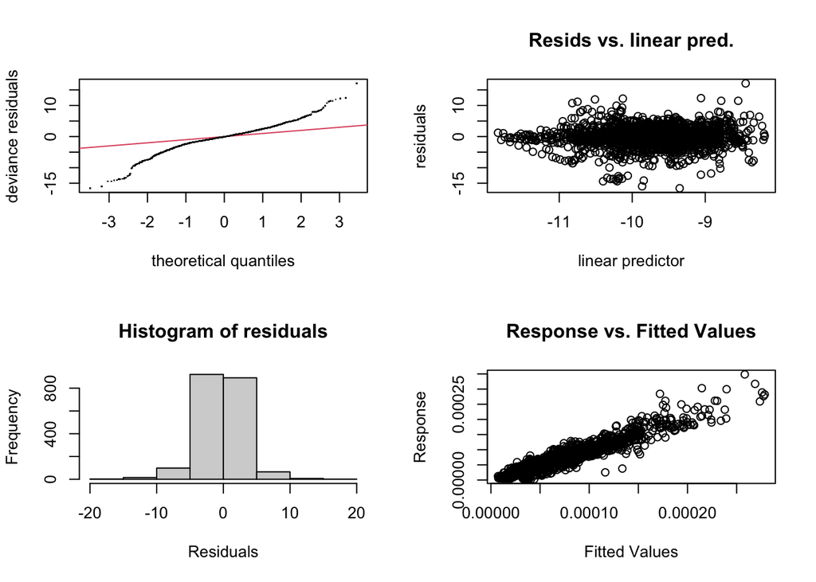

```
##
## Method: UBRE   Optimizer: outer newton
## full convergence after 7 iterations.
## Gradient range [5.064278e-08,2.529474e-05]
## (score 8.840989 & scale 1).
## Hessian positive definite, eigenvalue range [8.477283e-05,0.0004428833].
## Model rank =  95 / 95
##
## Basis dimension (k) checking results. Low p-value (k-index<1) may
## indicate that k is too low, especially if edf is close to k'.
##
##                                                k'  edf k-index p-value
## s(Time_Period_ID):as.factor(Region)Midwest   9.00 8.89    1.05    0.98
## s(Time_Period_ID):as.factor(Region)Northeast 9.00 8.96    1.05    0.98
## s(Time_Period_ID):as.factor(Region)South     9.00 8.93    1.05    0.97
## s(Time_Period_ID):as.factor(Region)West      9.00 8.22    1.05    0.98
```

```r
#check diagnostics
gam.check(main_analysis_model)
```

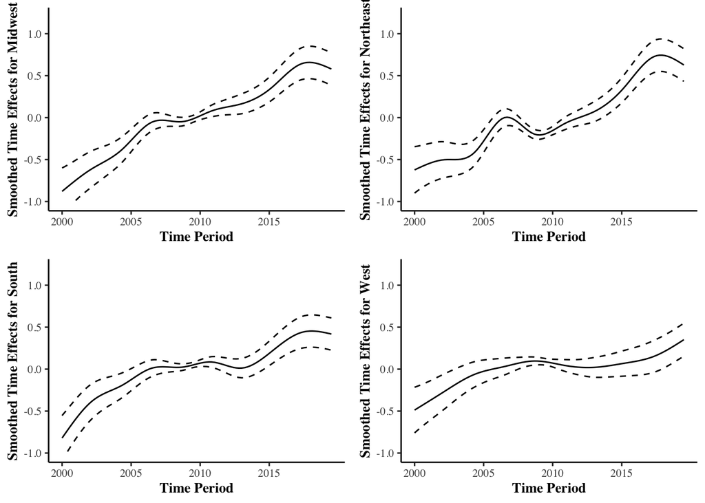

```r
main_analysis_model_object <- getViz(main_analysis_model)

midwest_plot <- plot(sm(main_analysis_model_object, 1)) +
  l_fitLine() +
  l_ciLine(mul = 5, linetype = 2)  +
  theme_classic() +
  labs(x = "Time Period", y = "Smoothed Time Effects for Midwest") +
  scale_x_continuous(breaks=c(1,11,21,31),
                     labels=c("2000", "2005", "2010", "2015"))  +
  theme(text=element_text(family="Times",size=10),
        title = element_text(family="Times", size=10, face = "bold"),
        panel.background = element_rect("white")) +
  ylim(c(-1,1.2))

northeast_plot <- plot(sm(main_analysis_model_object,2)) +
  l_fitLine() +
  l_ciLine(mul = 5, linetype = 2)  +
  theme_classic() +
  labs(x = "Time Period", y = "Smoothed Time Effects for Northeast") +
  scale_x_continuous(breaks=c(1,11,21,31),
                     labels=c("2000", "2005", "2010", "2015"))+
  theme(text=element_text(family="Times",size=10),
        title = element_text(family="Times", size=10, face = "bold"),
        panel.background = element_rect("white")) +
  ylim(c(-1,1.2))

south_plot <- plot(sm(main_analysis_model_object, 3)) +
  l_fitLine() +
  l_ciLine(mul = 5, linetype = 2)  +
  theme_classic() +
  labs(x = "Time Period", y = "Smoothed Time Effects for South") +
  scale_x_continuous(breaks=c(1,11,21,31),
                     labels=c("2000", "2005","2010", "2015"))+
  theme(text=element_text(family="Times",size=10),
        title = element_text(family="Times", size=10, face = "bold"),
        panel.background = element_rect("white")) +
  ylim(c(-1,1.2))

west_plot <- plot(sm(main_analysis_model_object, 4)) +
  l_fitLine() +
  l_ciLine(mul = 5, linetype = 2)  + theme_classic() +
  labs(x = "Time Period", y = "Smoothed Time Effects for West") +
  scale_x_continuous(breaks=c(1,11,21,31),
                     labels=c("2000", "2005", "2010", "2015"))+
  theme(text=element_text(family="Times",size=10),
        title = element_text(family="Times", size=10, face = "bold"),
        panel.background = element_rect("white")) +
  ylim(c(-1,1.2))

# pdf("./Figures/time_smoothed_effects_9_6_21.pdf")
gridPrint(midwest_plot, northeast_plot, south_plot, west_plot, ncol = 2)
```

```r
# dev.off()

total_pop <- main_analysis_data %>%
  group_by(year = year(Time_Period_Start), State) %>%
  summarise(pop = unique(population)) %>%
  group_by(year) %>%
  summarise(sum(pop))

main_analysis_data %>%
  group_by(year(Time_Period_Start)) %>%
  summarise(sum_deaths = sum(imputed_deaths)*100000) %>%
  mutate(sum_deaths/total_pop$`sum(pop)`)
```

```
## # A tibble: 20 x 3
##    `year(Time_Period_Start)`  sum_deaths `sum_deaths/total_pop$\`sum(pop)\``
##  *                     <dbl>       <dbl>                               <dbl>
##  1                      2000 1151390000                                 5.52
##  2                      2001 1276465000                                 6.03
##  3                      2002 1614890000                                 7.54
##  4                      2003 1799140000.                                8.31
##  5                      2004 1953250000                                 8.92
##  6                      2005 2216225000                                10.0
##  7                      2006 2603525000                                11.6
##  8                      2007 2730800000                                12.0
##  9                      2008 2787500000                                12.1
## 10                      2009 2848100000                                12.3
## 11                      2010 2969200000                                12.7
## 12                      2011 3276800000                                13.9
## 13                      2012 3291600000                                13.8
## 14                      2013 3541000000                                14.7
## 15                      2014 3847600000                                15.8
## 16                      2015 4381900000                                17.9
## 17                      2016 5433100000                                21.9
## 18                      2017 6084700000                                24.4
## 19                      2018 5847900000                                23.2
## 20                      2019 6166500000                                24.3
```

```r
main_analysis_data %>%
  group_by(State, year(Time_Period_Start)) %>%
  summarise(death_rate = (sum(imputed_deaths)/unique(population))*100000) %>%
  group_by(State) %>%
  summarise(first_death_rate = death_rate[1],
            last_death_rate = death_rate[20]) %>%
  mutate(range_death_rate = last_death_rate - first_death_rate) %>%
  filter(range_death_rate == min(range_death_rate) | range_death_rate == max(range_death_rate))
```

```
## # A tibble: 2 x 4
##   State         first_death_rate last_death_rate range_death_rate
##   <chr>                    <dbl>           <dbl>            <dbl>
## 1 Nebraska                  1.67            8.40             6.74
## 2 West Virginia             3.98           57.6             53.6
```

```r
#create a data frame to store the results and compute the confidence intervals
#initialize the columns
main_analysis_plot_table<-data.frame(State = main_analysis_data$State)
main_analysis_plot_table$Fitted<-rep(NA, nrow(main_analysis_plot_table))
main_analysis_plot_table$Observed<-rep(NA, nrow(main_analysis_plot_table))
main_analysis_plot_table$Time<-main_analysis_data$Time_Period_ID
main_analysis_plot_table$Time_Date<-main_analysis_data$Time_Period_Start
main_analysis_plot_table$Intervention_Date<-main_analysis_data$Intervention_First_Date

#we want to compare the fitted probability of overdose death and the observed values to see how the model does as a goodness of fit visual test
for(i in unique(main_analysis_plot_table$State)){
  #for each state, we first subset the main analysis data to only look at the data for that state
  index_of_state<-which(main_analysis_plot_table$State == i)
  #impute the fitted and observed probability of overdose death for the state
  main_analysis_plot_table$Fitted[index_of_state]<-fitted(main_analysis_model)[index_of_state]
  main_analysis_plot_table$Observed[index_of_state] <- (main_analysis_data$imputed_deaths[main_analysis_data$State == i]/main_analysis_data$population[main_analysis_data$State == i])
}
```

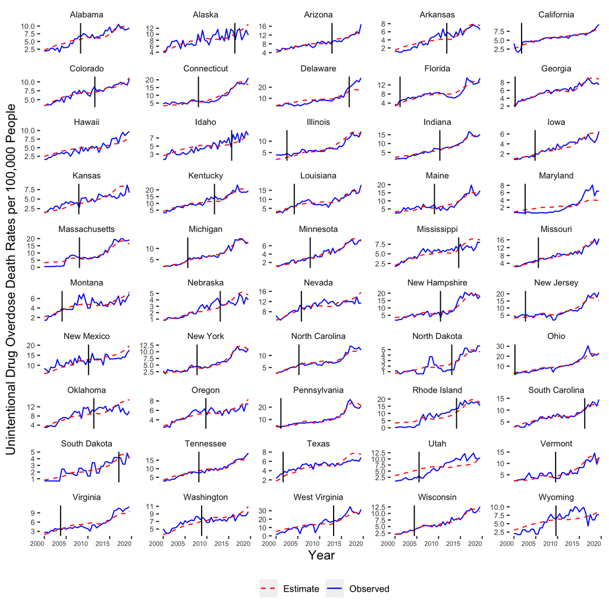

```r
#plot to compare the fitted values vs observed deaths
# pdf("./Figures/GAM_fitted_vs_actual_by_Region_5_10_22_with_int_date_full_data.pdf", height = 6, width = 6)
ggplot(data = main_analysis_plot_table) +
  geom_line(aes(color = "Observed", x = Time_Date, y = Observed*100000, group = 1,
                linetype = "Observed"))+
  # geom_point(aes(color = "Observed"), size = .5, alpha = .5) +
  geom_line(data = main_analysis_plot_table, aes(x = Time_Date, y = Fitted*100000, group = 1,
                                                 color = "Estimate", linetype = "Estimate")) +
  # geom_point(data = main_analysis_plot_table, aes(x = Time_Date, y = Fitted*100000,
  #                                                 color = "Estimate"),
  #            size = .5, alpha = .5) +
  scale_color_manual(values = c("red", "blue")) +
  scale_linetype_manual(values = c("dashed", "solid")) +
  geom_vline(main_analysis_plot_table, mapping = aes(xintercept = Intervention_Date)) +
  facet_wrap(facets = vars(State), scales = "free_y", ncol = 5) +
  theme(axis.text.x = element_text(hjust = 1, size = 6),
        axis.text.y = element_text(size = 7),
        axis.title=element_text(size = 12),
        panel.grid.major = element_blank(),
        panel.grid.minor = element_blank(),
        strip.background = element_blank(),
        strip.text = element_text(size=8),
        panel.background = element_rect("white"),
        legend.position = "bottom") +
  labs(x = "Year", y = "Unintentional Drug Overdose Death Rates per 100,000 People",
       color = "", linetype = "")
```

```r
# dev.off()
```

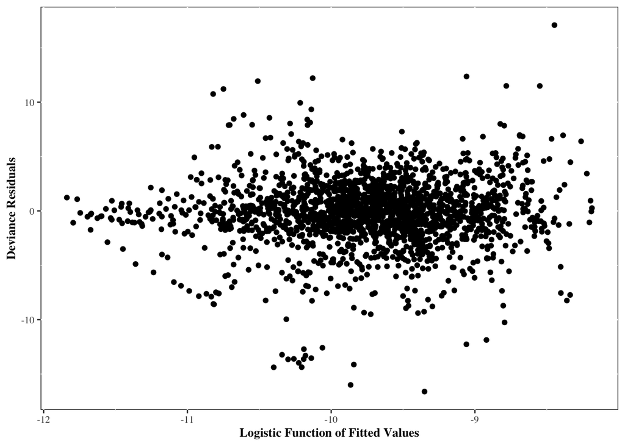

```r
#diagnostic plots to check model
residTab <- data.frame(logit_fitted_vals = logit(fitted(main_analysis_model)),
                       resids = residuals(main_analysis_model))
# pdf("./Figures/deviance_resids_1_18_22.pdf")
ggplot(residTab, aes(x = logit_fitted_vals, y = resids)) +
  geom_point() +
  theme(text = element_text(size = 10, family = "Times"),
        title = element_text(size = 10, family = "Times", face = "bold"),
        panel.background = element_rect(fill = "white", color = "black")) +
  # theme_classic() +
  labs(x = "Logistic Function of Fitted Values", y = "Deviance Residuals")
```

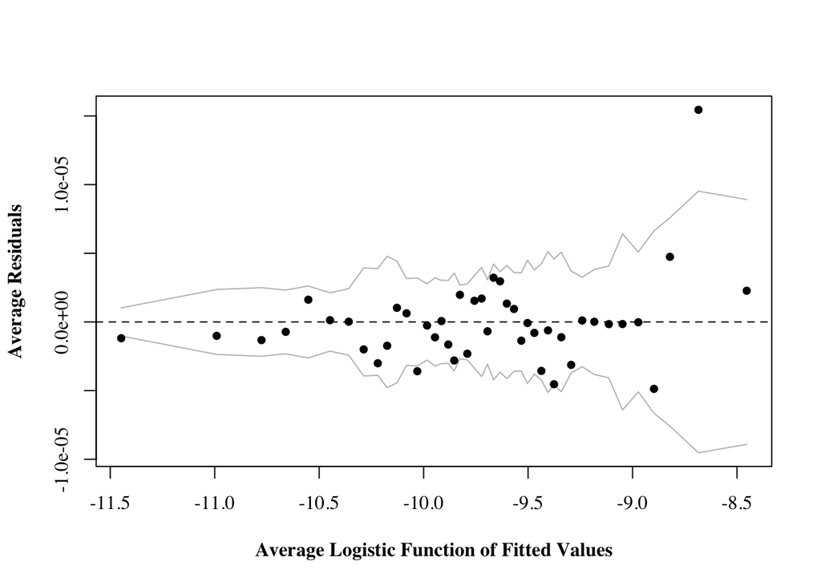

```r
# dev.off()

pred_vals <- predict(main_analysis_model)
resids <- resid(main_analysis_model, type = "response")
# pdf("./Figures/binned_resids_plot_9_6_21.pdf")
par(font.lab = 2)
par(family = "Times")
binnedplot(pred_vals, resids, main = "",
           xlab = "Average Logistic Function of Fitted Values",
           ylab = "Average Residuals")
```

```r
# dev.off()
```

### 3.1.4 Compile Results

```r
############################## Main Analysis: Make Data Frame of Results and 95% CI ###############################
#store the coefficients into the table
main_analysis_full_table<-main_analysis_sd_and_ci
#check to see how the table looks
head(main_analysis_full_table)
```

```
##                      lb_coef coef_values     ub_coef       exp_lb     exp_coef
## (Intercept)     -10.30848811 -9.91068390 -9.51287970 3.334882e-05 4.964147e-05
## StateAlaska       0.17549106  0.27712443  0.37875781 1.191831e+00 1.319331e+00
## StateArizona      0.24265985  0.31458505  0.38651024 1.274635e+00 1.369691e+00
## StateArkansas    -0.48359477 -0.39014795 -0.29670114 6.165630e-01 6.769567e-01
## StateCalifornia  -0.24006250 -0.15908174 -0.07810099 7.865787e-01 8.529266e-01
## StateColorado     0.01392024  0.09639187  0.17886351 1.014018e+00 1.101191e+00
##                       exp_ub    sd_coef
## (Intercept)     7.389394e-05 0.20296133
## StateAlaska     1.460469e+00 0.05185376
## StateArizona    1.471835e+00 0.03669653
## StateArkansas   7.432661e-01 0.04767695
## StateCalifornia 9.248710e-01 0.04131671
## StateColorado   1.195858e+00 0.04207736
```

```r
#vector of covariates
covariates<-c("Naloxone_Pharmacy_Yes_Redefined",
              "Naloxone_Pharmacy_No_Redefined",
              "Medical_Marijuana_Redefined",
              "Recreational_Marijuana_Redefined",
              "GSL_Redefined",
              "PDMP_Redefined",
              "Medicaid_Expansion_Redefined",
              "Intervention_Redefined",
              "num_states_w_intervention")

#rename the variable names of the regression output so that they look nicer:
#currently there are 3 types of coefficients: state effects, the covariates, and smoothed time effects
#for each row in the main analysis table
for(i in 1:length(rownames(main_analysis_full_table))){

  #if the coefficient is not in the covariates vector
  if(!(rownames(main_analysis_full_table)[i] %in% covariates)){

    #we see if it's a state effect
    if(substr(rownames(main_analysis_full_table)[i], start = 1, stop = 5) == "State"){

      #if so, here, the names look like: StateMassachusetts or StateGeorgia, so take out the "State" part
      #and just rename these rows to just the state name
      rownames(main_analysis_full_table)[i]<-substr(rownames(main_analysis_full_table)[i], start = 6,
                                                    stop = nchar(rownames(main_analysis_full_table)[i]))

    }else if(rownames(main_analysis_full_table)[i] == "(Intercept)"){

      #otherwise, if the current name is Intercept, we rename it so that we know that Alabama is the baseline
      rownames(main_analysis_full_table)[i]<-"Intercept/Alabama"

    }else if(substr(rownames(main_analysis_full_table)[i], start = 1, stop = 35) == "s(Time_Period_ID):as.factor(Region)"){

      #otherwise, it's the smoothed time effects which look like: s(Time_Period_ID):as.factor(Region)West
      #or s(Time_Period_ID):as.factor(Region)South, so we want to get rid of "s(Time_Period_ID):as.factor(Region)"
      #and change it to "Smoothed Time for Region"
      rownames(main_analysis_full_table)[i]<-paste("Smoothed Time for Region ",
                                                   substr(rownames(main_analysis_full_table)[i], start = 36,
                                                          stop = nchar(rownames(main_analysis_full_table)[i])),
                                                   sep = "")

    }
  }
}

head(main_analysis_full_table)
```

```
##                        lb_coef coef_values     ub_coef       exp_lb
## Intercept/Alabama -10.30848811 -9.91068390 -9.51287970 3.334882e-05
## Alaska              0.17549106  0.27712443  0.37875781 1.191831e+00
## Arizona             0.24265985  0.31458505  0.38651024 1.274635e+00
## Arkansas           -0.48359477 -0.39014795 -0.29670114 6.165630e-01
## California         -0.24006250 -0.15908174 -0.07810099 7.865787e-01
## Colorado            0.01392024  0.09639187  0.17886351 1.014018e+00
##                       exp_coef       exp_ub    sd_coef
## Intercept/Alabama 4.964147e-05 7.389394e-05 0.20296133
## Alaska            1.319331e+00 1.460469e+00 0.05185376
## Arizona           1.369691e+00 1.471835e+00 0.03669653
## Arkansas          6.769567e-01 7.432661e-01 0.04767695
## California        8.529266e-01 9.248710e-01 0.04131671
## Colorado          1.101191e+00 1.195858e+00 0.04207736
```

```r
tail(main_analysis_full_table)
```

```
##                                     lb_coef coef_values   ub_coef    exp_lb
## Smoothed Time for Region West.4  0.13011848   0.2352866 0.3404548 1.1389633
## Smoothed Time for Region West.5 -0.01705630   0.1835194 0.3840951 0.9830883
## Smoothed Time for Region West.6 -0.11943980   0.1609894 0.4414186 0.8874174
## Smoothed Time for Region West.7 -0.12674880   0.2035462 0.5338411 0.8809549
## Smoothed Time for Region West.8 -0.09951082   0.3083070 0.7161248 0.9052802
## Smoothed Time for Region West.9  0.07770438   0.4223217 0.7669390 1.0808031
##                                 exp_coef   exp_ub    sd_coef
## Smoothed Time for Region West.4 1.265271 1.405587 0.05365722
## Smoothed Time for Region West.5 1.201438 1.468285 0.10233453
## Smoothed Time for Region West.6 1.174673 1.554912 0.14307614
## Smoothed Time for Region West.7 1.225742 1.705471 0.16851783
## Smoothed Time for Region West.8 1.361119 2.046487 0.20807031
## Smoothed Time for Region West.9 1.525499 2.153165 0.17582516
```

```r
#save the table into a CSV
# write.csv(round(main_analysis_full_table,5), "./Data/coefficients_GAM_1_18_22_full_data_uninentional_od.csv")

#export a table with just the covariates
#first, find the rows that contains the covariates
covariate_Index<-which(rownames(main_analysis_full_table) %in% covariates)
main_analysis_covariate_table<-(round(main_analysis_full_table[covariate_Index,], 5))

#rename the variables so that it looks cleaner
rownames(main_analysis_covariate_table)<-c("Naloxone_Pharmacy_Yes",
                                           "Naloxone_Pharmacy_No",
                                           "Medical_Marijuana",
                                           "Recreational_Marijuana",
                                           "GSL",
                                           "PDMP",
                                           "Medicaid_Expansion",
                                           "Intervention",
                                           "Number of States with DIH Prosecutions")

#now, reorganize the data so that the covariates are on top and the rest of the variable sare below
main_analysis_covariate_table<-rbind(main_analysis_covariate_table,
                                     main_analysis_full_table[-covariate_Index,])
#remove the columns that aren't in odds ratio scale
main_analysis_covariate_table<-main_analysis_covariate_table[,-which(colnames(main_analysis_covariate_table) %in%
                                                                       c("lb_coef", "coef_values",
                                                                         "ub_coef"))]

colnames(main_analysis_covariate_table)<-c("RR_95_CI_LB", "Risk_Ratio_Estimates", "RR_95_CI_UB", "standard_error")
head(main_analysis_covariate_table, 10)
```

```
##                                         RR_95_CI_LB Risk_Ratio_Estimates
## Naloxone_Pharmacy_Yes                  9.265900e-01         9.761800e-01
## Naloxone_Pharmacy_No                   9.629900e-01         1.008440e+00
## Medical_Marijuana                      1.019280e+00         1.065010e+00
## Recreational_Marijuana                 9.127200e-01         9.638900e-01
## GSL                                    9.935600e-01         1.034430e+00
## PDMP                                   9.394400e-01         9.806800e-01
## Medicaid_Expansion                     1.060750e+00         1.104180e+00
## Intervention                           1.023510e+00         1.063780e+00
## Number of States with DIH Prosecutions 9.901400e-01         1.003700e+00
## Intercept/Alabama                      3.334882e-05         4.964147e-05
##                                         RR_95_CI_UB standard_error
## Naloxone_Pharmacy_Yes                  1.028420e+00      0.0266000
## Naloxone_Pharmacy_No                   1.056030e+00      0.0235300
## Medical_Marijuana                      1.112790e+00      0.0223900
## Recreational_Marijuana                 1.017930e+00      0.0278300
## GSL                                    1.076980e+00      0.0205700
## PDMP                                   1.023720e+00      0.0219200
## Medicaid_Expansion                     1.149390e+00      0.0204700
## Intervention                           1.105630e+00      0.0196900
## Number of States with DIH Prosecutions 1.017440e+00      0.0069400
## Intercept/Alabama                      7.389394e-05      0.2029613
```

```r
#save the table into a CSV
# write.csv(round(main_analysis_covariate_table, 3), "./Data/coefficients_covariates_4_20_22_full_data_unintentional_od.csv")
```

### 3.1.5 Attributable Deaths

```r
############################## Main Analysis: Number of Overdose Deaths Attributed to Intervention ###############################
#find the number of deaths attributable to the intervention
#first, we subset the data so that we only focus on the time points for which at least one state had the intervention
attr_deaths_anlys_main_analysis<-main_analysis_data[which(main_analysis_data$Intervention_Redefined>0),]

#compute the probability of overdose had intervention not occurred
prob_od_no_int_main_analysis<-expit(-coef(main_analysis_model)["Intervention_Redefined"]*
                                      attr_deaths_anlys_main_analysis$Intervention_Redefined
                                    + logit(attr_deaths_anlys_main_analysis$imputed_deaths/
                                              attr_deaths_anlys_main_analysis$population))

#compute the lower and upper bounds of 95% CI of probability of overdose had intervention not occurred
#here, we compute the lower and upper bounds of the 95% CI of all the coefficients using the standard error from the model
coef_lb<-main_analysis_full_table$lb_coef
coef_ub<-main_analysis_full_table$ub_coef
names(coef_lb) <- names(coef_ub) <- rownames(main_analysis_full_table)

#we then calculate the upper and lower bounds of the probability of overdose death had intervention not occurred by using
#the lower and upper bounds of the coefficient of the intervention variable
prob_od_no_int_LB_main_analysis<-expit(-coef_lb[names(coef_lb) ==
                                                  "Intervention_Redefined"]*attr_deaths_anlys_main_analysis$Intervention_Redefined
                                       + logit(attr_deaths_anlys_main_analysis$imputed_deaths/attr_deaths_anlys_main_analysis$population))

prob_od_no_int_UB_main_analysis<-expit(-coef_ub[names(coef_ub) ==
                                                  "Intervention_Redefined"]*attr_deaths_anlys_main_analysis$Intervention_Redefined
                                       + logit(attr_deaths_anlys_main_analysis$imputed_deaths/attr_deaths_anlys_main_analysis$population))

#estimate the number of deaths attributable to the intervention
#first, initialize the vectors to store the numbers
num_attr_od_UB<-num_attr_od_LB<-num_attr_od<-rep(NA, length(unique(attr_deaths_anlys_main_analysis$Time_Period_ID)))


#for each time period, we first find the indices of rows containing data from that time point
#then, we find the total number of deaths that attributable to the intervention

index<-1 #keep track of where to store the values in the vector

for(time in sort(unique(attr_deaths_anlys_main_analysis$Time_Period_ID))){
  #find the indices of rows where the time point = time
  time_point_index<-which(attr_deaths_anlys_main_analysis$Time_Period_ID == time)

  #find the number of deaths attributable to intervention = observed number of deaths with intervention - estimated number of deaths had intervention not occurred
  num_attr_od[index]<-sum(attr_deaths_anlys_main_analysis$imputed_deaths[time_point_index]
                          - prob_od_no_int_main_analysis[time_point_index]*
                            attr_deaths_anlys_main_analysis$population[time_point_index])
  #find the lower and upper bounds of the estimated number of deaths attributable to the intervention
  num_attr_od_LB[index]<-sum(attr_deaths_anlys_main_analysis$imputed_deaths[time_point_index]
                             - prob_od_no_int_LB_main_analysis[time_point_index]*
                               attr_deaths_anlys_main_analysis$population[time_point_index])
  num_attr_od_UB[index]<-sum(attr_deaths_anlys_main_analysis$imputed_deaths[time_point_index]
                             - prob_od_no_int_UB_main_analysis[time_point_index]*
                               attr_deaths_anlys_main_analysis$population[time_point_index])
  index<-index + 1
}

num_attr_od_main_analysis<-data.frame("Time_Period_ID" = sort(unique(attr_deaths_anlys_main_analysis$Time_Period_ID)),
                                      "Time_Start" = sort(unique(attr_deaths_anlys_main_analysis$Time_Period_Start)),
                                      "Num_Attr_Deaths" = num_attr_od,
                                      "Num_Attr_Deaths_LB" = num_attr_od_LB,
                                      "Num_Attr_Deaths_UB" = num_attr_od_UB)

#sum up the total number of excess deaths attributable to the intervention
sum(num_attr_od_main_analysis$Num_Attr_Deaths)
```

```
## [1] 33114.98
```

```r
summary(num_attr_od_main_analysis$Num_Attr_Deaths)
```

```
##     Min.  1st Qu.   Median     Mean  3rd Qu.     Max.
##    9.971  355.713  702.014  827.874 1154.626 1931.467
```

```r
num_attr_od_main_analysis$Time_Start<-as.Date(num_attr_od_main_analysis$Time_Start)

#compute the 95% CI for the total
sum(num_attr_od_main_analysis$Num_Attr_Deaths_LB)
```

```
## [1] 12683.82
```

```r
sum(num_attr_od_main_analysis$Num_Attr_Deaths_UB)
```

```
## [1] 52775.96
```

```r
#sum up the number of excess deaths per year
yearly_num_Attr_Deaths_main_analysis<-num_attr_od_main_analysis %>%
  group_by("year" = year(Time_Start)) %>%
  summarise("deaths" = sum(Num_Attr_Deaths), death_lb = sum(Num_Attr_Deaths_LB),
            death_ub = sum(Num_Attr_Deaths_UB))

summary(yearly_num_Attr_Deaths_main_analysis$deaths)
```

```
##    Min. 1st Qu.  Median    Mean 3rd Qu.    Max.
##   29.82  753.33 1409.54 1655.75 2306.53 3684.37
```

```r
summary(yearly_num_Attr_Deaths_main_analysis$death_lb)
```

```
##    Min. 1st Qu.  Median    Mean 3rd Qu.    Max.
##   11.38  288.47  539.89  634.19  883.51 1411.31
```

```r
summary(yearly_num_Attr_Deaths_main_analysis$death_ub)
```

```
##    Min. 1st Qu.  Median    Mean 3rd Qu.    Max.
##   47.67 1200.87 2246.41 2638.80 3675.74 5871.41
```

```r
sum(yearly_num_Attr_Deaths_main_analysis$deaths)/sum(main_analysis_data$imputed_deaths)
```

```
## [1] 0.05031021
```

```r
sum(yearly_num_Attr_Deaths_main_analysis$death_lb)/sum(main_analysis_data$imputed_deaths)
```

```
## [1] 0.01927001
```

```r
sum(yearly_num_Attr_Deaths_main_analysis$death_ub)/sum(main_analysis_data$imputed_deaths)
```

```
## [1] 0.08018033
```

## 3.2 Secondary Analysis: Assuming Effect Lasts for Two Years

### 3.2.1 Analysis

```r
########### Sensitivity Analysis 2: Two Year Intervention Effect ######################
#create a plot for each state to see how many prosecution media alerts there are per 6 month period
#read in the prosecution media alert data
prosecution_data<-read.csv("./Data/dih_prosecutions_9_6_21.csv")

#data cleaning
prosecution_data<-prosecution_data %>%
  mutate(Date = as.Date(Date.charged, "%m/%d/%Y")) %>%
  mutate(State = ifelse(State.Filed == "pennsylvania", "Pennsylvania", State.Filed),
         State = ifelse(State.Filed == "Virginia ", "Virginia", State)) %>%
  filter(!is.na(Date), State.Filed != "No Info", State.Filed != "No info", State.Filed != "No Info ",
         State != "")

#clean up the data by looking at the link to the article
prosecution_data$Date[prosecution_data$Date == "2026-08-01"] <- as.Date("2016-02-15", "%Y-%m-%d")

#change the states into Character instead of factor
prosecution_data$State<-as.character(prosecution_data$State)
#see how many prosecution data points there are for each state
table(prosecution_data$State)
```

```
   Alabama         Alaska        Arizona       Arkansas     California
        12              8              9              4             76
  Colorado    Connecticut       Delaware        Florida        Georgia
        32             47              3            138             29
     Idaho       Illinois        Indiana           Iowa         Kansas
         9            342             55             31              9
  Kentucky      Louisiana          Maine       Maryland  Massachusetts
        43             65             17             63             34
  Michigan      Minnesota    Mississippi       Missouri        Montana
       116            140              1             45             11
  Nebraska         Nevada  New Hampshire     New Jersey     New Mexico
         1             13             42            137              4
  New York North Carolina   North Dakota           Ohio       Oklahoma
       110            124             53            404             41
    Oregon   Pennsylvania   Rhode Island South Carolina   South Dakota
        19            726              2             12             13
 Tennessee          Texas           Utah        Vermont       Virginia
        94             44             21             13             63
Washington  West Virginia      Wisconsin        Wyoming
        78             33            381             19
```

```r
#there are some repeated cases depending on victim
prosecution_data_unique <- prosecution_data %>%
  group_by(State) %>%
  distinct(Accused.Name, Date, .keep_all = T)
table(prosecution_data_unique$State)
```

```
   Alabama         Alaska        Arizona       Arkansas     California
        12              8              9              4             72
  Colorado    Connecticut       Delaware        Florida        Georgia
        30             46              3            134             26
     Idaho       Illinois        Indiana           Iowa         Kansas
         9            336             53             31              9
  Kentucky      Louisiana          Maine       Maryland  Massachusetts
        43             65             17             62             34
  Michigan      Minnesota    Mississippi       Missouri        Montana
       114            140              1             44             10
  Nebraska         Nevada  New Hampshire     New Jersey     New Mexico
         1             13             42            131              4
  New York North Carolina   North Dakota           Ohio       Oklahoma
       105            121             40            395             34
    Oregon   Pennsylvania   Rhode Island South Carolina   South Dakota
        19            718              2             12             13
 Tennessee          Texas           Utah        Vermont       Virginia
        94             43             21             13             63
Washington  West Virginia      Wisconsin        Wyoming
        75             33            373             19
```

```r
#change date charged into Date object
prosecution_data_unique$Date<-mdy(prosecution_data_unique$Date.charged)

#group the data into six month periods
prosecution_data_unique<-prosecution_data_unique %>%
  mutate(six_month_pd = lubridate::floor_date(Date , "6 months" ))

#count the number of prosecution media alerts in each six month period
#we also get the first and last date of prosecution in time period
prosecution_data_by_six_month_pd <- prosecution_data_unique %>%
  filter(year(six_month_pd)>1999 & year(six_month_pd)<2020) %>%
  group_by(State, six_month_pd) %>%
  summarise(first_date_in_pd = min(Date), last_date_in_pd = max(Date))

#create the data set used for this sensitivity analysis
#first, we merge the grouped prosecution data set with the main data set by state and time period
sensitivity_anlys_redefine_int_data<-merge(main_analysis_data,
                                           prosecution_data_by_six_month_pd,
                                           by.x = c("State", "Time_Period_Start"),
                                           by.y = c("State", "six_month_pd"), all = TRUE)

#create a intervention 2 year effect variable by initializing it to be all 0
sensitivity_anlys_redefine_int_data<-sensitivity_anlys_redefine_int_data %>%
  group_by(State) %>%
  mutate(int_2_yr_effect = 0)

#change the date into a date object
sensitivity_anlys_redefine_int_data$Time_Period_Start<-as.Date(sensitivity_anlys_redefine_int_data$Time_Period_Start)
sensitivity_anlys_redefine_int_data$Time_Period_End<-as.Date(sensitivity_anlys_redefine_int_data$Time_Period_End)

#we need to impute the newly defined intervention variable depending on the case
#by examining each row of the data set
for(state in unique(sensitivity_anlys_redefine_int_data$State)){
  #first, subset the data set into state_data which only contains the data for the state
  state_index<-which(sensitivity_anlys_redefine_int_data$State == state)
  state_data<-sensitivity_anlys_redefine_int_data[state_index,]

  #note that the first four rows of the 2 year effect intervention variable are the same as the
  #first four rows of the original intervention variable
  state_data$int_2_yr_effect[1:4]<-state_data$Intervention_Redefined[1:4]

  for(i in 5:nrow(state_data)){
    #next, we deal with the rows where there was at least one prosecution in the last 3 six month periods
    #These rows will be imputed with a 1
    if((!is.na(state_data$first_date_in_pd[i - 1]) |
        !is.na(state_data$first_date_in_pd[i - 2]) |
        !is.na(state_data$first_date_in_pd[i - 3]))){

      state_data$int_2_yr_effect[i]<-1

    }else{
      #next, we account for the rows with the fractions:
      # 1) an intervention occurs in row i without an intervention 2 years ago
      # 2) row i contains the lasting effects of an intervention that occurred 2 years ago
      # 3) row i contains effects from both a new intervention starting in row i and lasting
      # effects from 2 years ago

      #To compute the fraction, we add the number of days that are affected by an intervention
      #(from both the current prosecution and previous prosecution) and then divide by the total
      #number of days in the period:

      total_len_of_pd<-as.numeric(state_data$Time_Period_End[i] - state_data$Time_Period_Start[i])

      #If there is no prosecution two years ago, i.e. in period i-4, then the last_date is the first
      #date in period i. We subtract the last_date by the first date in the period, so we will get
      #a 0 for the number of days that are affected by a prosecution from period i-4. Otherwise,
      #the last_date is the last date of prosecution from period i-4, plus 2 years.
      len_of_past_effect <- ifelse(!is.na(state_data$first_date_in_pd[i - 4]),
                                   (state_data$last_date_in_pd[i - 4] + years(2)) - state_data$Time_Period_Start[i],
                                   0)

      #If there is no prosecution in the period i, then the start_date is the last date in the period i.
      #We subtract start_date from the last date in period i, so we will get a 0 for the number
      #of days that are affected by a prosecution in period i. Otherwise, the start_date is the
      #first date of a prosecution in period i.
      len_of_current_effect <- ifelse(!is.na(state_data$first_date_in_pd[i]),
                                      as.numeric(state_data$Time_Period_End[i] - state_data$first_date_in_pd[i]),
                                      0)

      state_data$int_2_yr_effect[i]<-(len_of_past_effect + len_of_current_effect)/total_len_of_pd
    }
  }

  #for the case where the int_2_yr_effect is greater than 1 (could result when we add the effects of
  #previous intervention and the current intervention), we just impute a 1 instead
  state_data$int_2_yr_effect[state_data$int_2_yr_effect>1]<-1

  #lastly, we store the int_2_yr_effect variable into the sensitivity analysis data set
  sensitivity_anlys_redefine_int_data$int_2_yr_effect[state_index]<-state_data$int_2_yr_effect
}

#view the data set just to make sure the imputation looks right
# View(sensitivity_anlys_redefine_int_data %>% select(State, Time_Period_Start, Time_Period_End,
#                                                     Intervention_Redefined, first_date_in_pd,
#                                                     last_date_in_pd,
#                                                     int_2_yr_effect))


sensitivity_anlys_redefine_int_data <- sensitivity_anlys_redefine_int_data %>%
  group_by(Time_Period_Start) %>%
  mutate(num_states_w_intervention_2_yr_effect = sum(int_2_yr_effect))

#run the analysis on the sensitivity analysis data
sensitivity_anlys_redefine_int_model<-gam(cbind(round(imputed_deaths), round(num_alive))~ State +
                                            s(Time_Period_ID, bs = "cr", by = as.factor(Region))  +
                                            Naloxone_Pharmacy_Yes_Redefined +
                                            Naloxone_Pharmacy_No_Redefined +
                                            Medical_Marijuana_Redefined +
                                            Recreational_Marijuana_Redefined +
                                            GSL_Redefined +
                                            PDMP_Redefined +
                                            Medicaid_Expansion_Redefined +
                                            int_2_yr_effect +
                                            num_states_w_intervention_2_yr_effect,
                                          data = sensitivity_anlys_redefine_int_data, family = "binomial")

# stargazer(sensitivity_anlys_redefine_int_model, type = "html", dep.var.labels = "Unintentional Overdose Death")
summary(sensitivity_anlys_redefine_int_model)
```

Family: binomial Link function: logit

Formula: cbind(round(imputed_deaths), round(num_alive)) ~ State + s(Time_Period_ID, bs = “cr”, by = as.factor(Region)) + Naloxone_Pharmacy_Yes_Redefined + Naloxone_Pharmacy_No_Redefined + Medical_Marijuana_Redefined + Recreational_Marijuana_Redefined + GSL_Redefined + PDMP_Redefined + Medicaid_Expansion_Redefined + int_2_yr_effect + num_states_w_intervention_2_yr_effect

Parametric coefficients: Estimate Std. Error z value Pr(>|z|) (Intercept) -9.737771 0.027665 -351.987 < 2e-16 StateAlaska 0.263528 0.027519 9.576 < 2e-16 StateArizona 0.315394 0.013929 22.642 < 2e-16 StateArkansas -0.369415 0.019795 -18.662 < 2e-16 StateCalifornia -0.157384 0.013247 -11.881 < 2e-16 StateColorado 0.087005 0.016004 5.437 5.43e-08 StateConnecticut 0.179121 0.015584 11.494 < 2e-16 StateDelaware 0.420462 0.022210 18.931 < 2e-16 StateFlorida 0.248385 0.011878 20.911 < 2e-16 StateGeorgia -0.055728 0.013256 -4.204 2.62e-05 StateHawaii -0.240700 0.025396 -9.478 < 2e-16 StateIdaho -0.141737 0.023747 -5.969 2.39e-09 StateIllinois -0.020502 0.013018 -1.575 0.11530 StateIndiana 0.082122 0.013866 5.923 3.17e-09 StateIowa -0.739686 0.021397 -34.570 < 2e-16 StateKansas -0.310044 0.019485 -15.912 < 2e-16 StateKentucky 0.634431 0.013654 46.465 < 2e-16 StateLouisiana 0.293420 0.014241 20.604 < 2e-16 StateMaine 0.142148 0.021506 6.610 3.85e-11 StateMaryland -1.067357 0.019338 -55.194 < 2e-16 StateMassachusetts 0.207658 0.013777 15.073 < 2e-16 StateMichigan -0.027978 0.013630 -2.053 0.04010 StateMinnesota -0.627717 0.017320 -36.242 < 2e-16 StateMississippi -0.089340 0.018169 -4.917 8.78e-07 StateMissouri 0.196517 0.014534 13.521 < 2e-16 StateMontana -0.353627 0.029474 -11.998 < 2e-16 StateNebraska -0.862968 0.028600 -30.173 < 2e-16 StateNevada 0.443412 0.016511 26.856 < 2e-16 StateNew Hampshire 0.250244 0.019741 12.676 < 2e-16 StateNew Jersey 0.109660 0.013283 8.256 < 2e-16 StateNew Mexico 0.640977 0.016980 37.748 < 2e-16 StateNew York -0.244496 0.012611 -19.387 < 2e-16 StateNorth Carolina 0.176859 0.012720 13.904 < 2e-16 StateNorth Dakota -1.060284 0.045485 -23.311 < 2e-16 StateOhio 0.450298 0.012300 36.609 < 2e-16 StateOklahoma 0.380747 0.014778 25.764 < 2e-16 StateOregon -0.201809 0.017830 -11.318 < 2e-16 StatePennsylvania 0.429853 0.012124 35.455 < 2e-16 StateRhode Island 0.245094 0.021748 11.270 < 2e-16 StateSouth Carolina 0.215623 0.014547 14.823 < 2e-16 StateSouth Dakota -0.965348 0.042528 -22.699 < 2e-16 StateTennessee 0.445548 0.012996 34.284 < 2e-16 StateTexas -0.196809 0.012078 -16.295 < 2e-16 StateUtah 0.080818 0.017953 4.502 6.74e-06 StateVermont -0.162469 0.031201 -5.207 1.92e-07 StateVirginia -0.113666 0.013747 -8.269 < 2e-16 StateWashington 0.064277 0.015440 4.163 3.14e-05 StateWest Virginia 0.867688 0.015385 56.398 < 2e-16 StateWisconsin -0.040331 0.014524 -2.777 0.00549 StateWyoming 0.025715 0.033643 0.764 0.44465 Naloxone_Pharmacy_Yes_Redefined -0.034129 0.007797 -4.377 1.20e-05 Naloxone_Pharmacy_No_Redefined 0.002860 0.006530 0.438 0.66138 Medical_Marijuana_Redefined 0.067481 0.005664 11.913 < 2e-16 Recreational_Marijuana_Redefined -0.039192 0.008632 -4.540 5.62e-06 GSL_Redefined 0.036085 0.005635 6.404 1.51e-10 PDMP_Redefined -0.016825 0.005804 -2.899 0.00375 Medicaid_Expansion_Redefined 0.102724 0.006040 17.008 < 2e-16 int_2_yr_effect 0.057551 0.004702 12.239 < 2e-16 num_states_w_intervention_2_yr_effect -0.002457 0.001033 -2.378 0.01738

R-sq.(adj) = 0.911 Deviance explained = 90.3% UBRE = 8.8346 Scale est. = 1 n = 2000

### 3.2.2 Sandwich Estimator

```r
sensitivity_anlys_redefine_int_data$prop_dead <- sensitivity_anlys_redefine_int_data$imputed_deaths/
  sensitivity_anlys_redefine_int_data$population
#compute the full dataset including basis functions
sensitivity_anlys_redefine_int_w_basis_functions <- as.matrix(predict(sensitivity_anlys_redefine_int_model, type = "lpmatrix"))

#estimate the 95% CI and SD
sensitivity_anlys_redefine_int_coefficient_values <- coef(sensitivity_anlys_redefine_int_model)
#type = "response" to get the estimated probabilities
sensitivity_anlys_redefine_int_pred_prob <- predict(sensitivity_anlys_redefine_int_model,
                                                    newdata = sensitivity_anlys_redefine_int_data, type = "response")
sensitivity_anlys_redefine_int_sd_and_ci <- compute_sd_and_CI(sensitivity_anlys_redefine_int_w_basis_functions,
                                                              (sensitivity_anlys_redefine_int_data$prop_dead),
                                                              sensitivity_anlys_redefine_int_coefficient_values,
                                                              l = ncol(sensitivity_anlys_redefine_int_w_basis_functions))
sensitivity_anlys_redefine_int_sd_and_ci
```

```
##                                                     lb_coef  coef_values
## (Intercept)                                    -9.932727687 -9.737771252
## StateAlaska                                     0.163168924  0.263527810
## StateArizona                                    0.243355997  0.315394401
## StateArkansas                                  -0.463915893 -0.369414931
## StateCalifornia                                -0.238526044 -0.157384034
## StateColorado                                   0.004665562  0.087005464
## StateConnecticut                                0.092751387  0.179120542
## StateDelaware                                   0.291065646  0.420461658
## StateFlorida                                    0.172537070  0.248384532
## StateGeorgia                                   -0.123041797 -0.055728270
## StateHawaii                                    -0.343413772 -0.240700027
## StateIdaho                                     -0.231420323 -0.141736838
## StateIllinois                                  -0.107744813 -0.020501556
## StateIndiana                                    0.009037691  0.082121847
## StateIowa                                      -0.827003428 -0.739686479
## StateKansas                                    -0.407636656 -0.310044217
## StateKentucky                                   0.560212788  0.634430992
## StateLouisiana                                  0.218265649  0.293420498
## StateMaine                                      0.042599651  0.142147676
## StateMaryland                                  -1.283492098 -1.067357140
## StateMassachusetts                              0.101571132  0.207658146
## StateMichigan                                  -0.102091477 -0.027978126
## StateMinnesota                                 -0.709315157 -0.627717375
## StateMississippi                               -0.167252162 -0.089339871
## StateMissouri                                   0.118310513  0.196517118
## StateMontana                                   -0.444433907 -0.353626919
## StateNebraska                                  -0.959267375 -0.862968400
## StateNevada                                     0.358400911  0.443411576
## StateNew Hampshire                              0.160489492  0.250244307
## StateNew Jersey                                 0.011493377  0.109659747
## StateNew Mexico                                 0.552019801  0.640977428
## StateNew York                                  -0.320882599 -0.244495717
## StateNorth Carolina                             0.109336302  0.176858589
## StateNorth Dakota                              -1.184349208 -1.060283820
## StateOhio                                       0.365011345  0.450298403
## StateOklahoma                                   0.279596019  0.380746668
## StateOregon                                    -0.286333130 -0.201809236
## StatePennsylvania                               0.356318277  0.429853032
## StateRhode Island                               0.117294828  0.245094454
```

[output cut: 329 more lines]

```
## s(Time_Period_ID):as.factor(Region)South.4     0.039227836
## s(Time_Period_ID):as.factor(Region)South.5     0.058489425
## s(Time_Period_ID):as.factor(Region)South.6     0.070004460
## s(Time_Period_ID):as.factor(Region)South.7     0.089598349
## s(Time_Period_ID):as.factor(Region)South.8     0.108707177
## s(Time_Period_ID):as.factor(Region)South.9     0.111810527
## s(Time_Period_ID):as.factor(Region)West.1      0.067580047
## s(Time_Period_ID):as.factor(Region)West.2      0.049003057
## s(Time_Period_ID):as.factor(Region)West.3      0.043066060
## s(Time_Period_ID):as.factor(Region)West.4      0.035385264
## s(Time_Period_ID):as.factor(Region)West.5      0.058523600
## s(Time_Period_ID):as.factor(Region)West.6      0.069947969
## s(Time_Period_ID):as.factor(Region)West.7      0.090978690
## s(Time_Period_ID):as.factor(Region)West.8      0.109398646
## s(Time_Period_ID):as.factor(Region)West.9      0.102730893
```

### 3.2.3 Plots

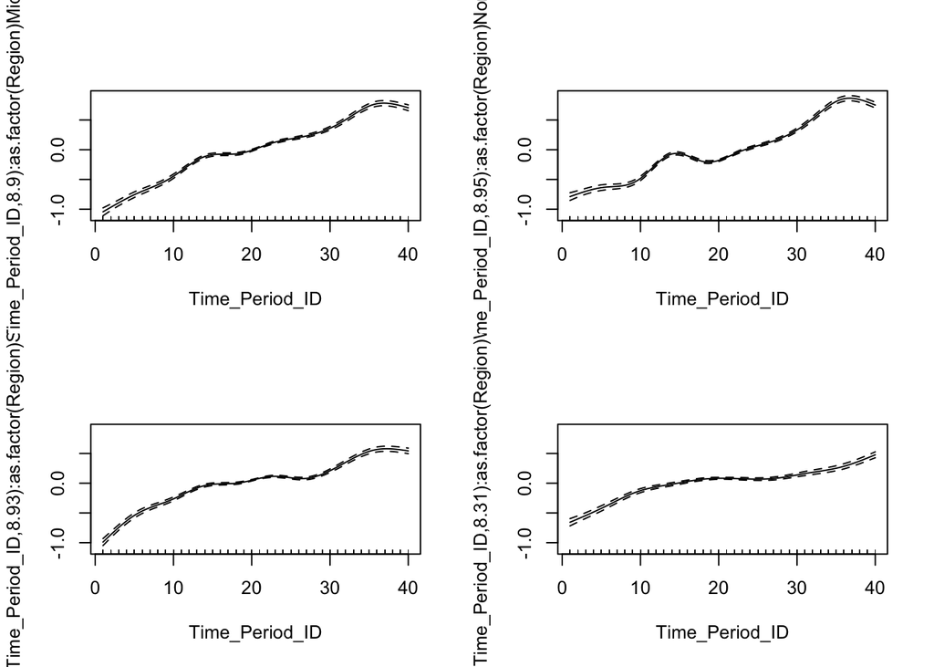

```r
plot(sensitivity_anlys_redefine_int_model, pages = 1)
```

### 3.2.4 Compile Results

```r
############## Sensitivity Analysis 4: Make Data Frame of Results and 95% CI ##########
#store the coefficients into the table
sensitivity_anlys_redefine_int_full_table<-sensitivity_anlys_redefine_int_sd_and_ci

#vector of covariates
covariates<-c("Naloxone_Pharmacy_Yes_Redefined",
              "Naloxone_Pharmacy_No_Redefined",
              "Medical_Marijuana_Redefined",
              "Recreational_Marijuana_Redefined",
              "GSL_Redefined",
              "PDMP_Redefined",
              "Medicaid_Expansion_Redefined",
              "int_2_yr_effect",
              "num_states_w_intervention_2_yr_effect")

#rename the variable names of the regression output so that they look nicer:
#currently there are 3 types of coefficients: state effects, the covariates, and smoothed time effects
#for each row in the main analysis table
for(i in 1:length(rownames(sensitivity_anlys_redefine_int_full_table))){

  #if the coefficient is not in the covariates vector
  if(!(rownames(sensitivity_anlys_redefine_int_full_table)[i] %in% covariates)){

    #we see if it's a state effect
    if(substr(rownames(sensitivity_anlys_redefine_int_full_table)[i], start = 1, stop = 5) == "State"){

      #if so, here, the names look like: StateMassachusetts or StateGeorgia, so take out the "State" part
      #and just rename these rows to just the state name
      rownames(sensitivity_anlys_redefine_int_full_table)[i]<-substr(rownames(sensitivity_anlys_redefine_int_full_table)[i], start = 6,
                                                                     stop = nchar(rownames(sensitivity_anlys_redefine_int_full_table)[i]))

    }else if(rownames(sensitivity_anlys_redefine_int_full_table)[i] == "(Intercept)"){

      #otherwise, if the current name is Intercept, we rename it so that we know that Alabama is the baseline
      rownames(sensitivity_anlys_redefine_int_full_table)[i]<-"Intercept/Alabama"

    }else if(substr(rownames(sensitivity_anlys_redefine_int_full_table)[i], start = 1, stop = 35) == "s(Time_Period_ID):as.factor(Region)"){

      #otherwise, it's the smoothed time effects which look like: s(Time_Period_ID):as.factor(Region)West
      #or s(Time_Period_ID):as.factor(Region)South, so we want to get rid of "s(Time_Period_ID):as.factor(Region)"
      #and change it to "Smoothed Time for Region"
      rownames(sensitivity_anlys_redefine_int_full_table)[i]<-paste("Smoothed Time for Region ",
                                                                    substr(rownames(sensitivity_anlys_redefine_int_full_table)[i], start = 36,
                                                                           stop = nchar(rownames(sensitivity_anlys_redefine_int_full_table)[i])),
                                                                    sep = "")

    }
  }
}

head(sensitivity_anlys_redefine_int_full_table)
```

```
##                        lb_coef coef_values     ub_coef       exp_lb
## Intercept/Alabama -9.932727687 -9.73777125 -9.54281482 4.855916e-05
## Alaska             0.163168924  0.26352781  0.36388670 1.177236e+00
## Arizona            0.243355997  0.31539440  0.38743280 1.275523e+00
## Arkansas          -0.463915893 -0.36941493 -0.27491397 6.288164e-01
## California        -0.238526044 -0.15738403 -0.07624202 7.877882e-01
## Colorado           0.004665562  0.08700546  0.16934536 1.004676e+00
##                       exp_coef       exp_ub    sd_coef
## Intercept/Alabama 5.901191e-05 0.0000717147 0.09946757
## Alaska            1.301513e+00 1.4389111707 0.05120351
## Arizona           1.370800e+00 1.4731939582 0.03675429
## Arkansas          6.911386e-01 0.7596374731 0.04821478
## California        8.543759e-01 0.9265919210 0.04139898
## Colorado          1.090903e+00 1.1845291628 0.04201015
```

```r
tail(sensitivity_anlys_redefine_int_full_table)
```

```
##                                   lb_coef coef_values   ub_coef   exp_lb
## Smoothed Time for Region West.4 0.1888174   0.2581725 0.3275276 1.207820
## Smoothed Time for Region West.5 0.1477856   0.2624918 0.3771981 1.159264
## Smoothed Time for Region West.6 0.1303438   0.2674418 0.4045399 1.139220
## Smoothed Time for Region West.7 0.1718068   0.3501250 0.5284433 1.187448
## Smoothed Time for Region West.8 0.2681985   0.4826199 0.6970412 1.307607
## Smoothed Time for Region West.9 0.3723084   0.5736609 0.7750135 1.451080
##                                 exp_coef   exp_ub    sd_coef
## Smoothed Time for Region West.4 1.294562 1.387533 0.03538526
## Smoothed Time for Region West.5 1.300166 1.458193 0.05852360
## Smoothed Time for Region West.6 1.306618 1.498613 0.06994797
## Smoothed Time for Region West.7 1.419245 1.696290 0.09097869
## Smoothed Time for Region West.8 1.620314 2.007803 0.10939865
## Smoothed Time for Region West.9 1.774752 2.170621 0.10273089
```

```r
#export a table with just the covariates
#first, find the rows that contains the covariates
covariate_Index<-which(rownames(sensitivity_anlys_redefine_int_full_table) %in% covariates)
sensitivity_anlys_redefine_int_covariate_table<-(round(sensitivity_anlys_redefine_int_full_table[covariate_Index,], 5))

#rename the variables so that it looks cleaner
rownames(sensitivity_anlys_redefine_int_covariate_table)<-c("Naloxone_Pharmacy_Yes",
                                                            "Naloxone_Pharmacy_No",
                                                            "Medical_Marijuana",
                                                            "Recreational_Marijuana",
                                                            "GSL",
                                                            "PDMP",
                                                            "Medicaid_Expansion",
                                                            "Two Year Intervention Effect",
                                                            "Number of States w Intervention")

#now, reorganize the data so that the covariates are on top and the rest of the variable sare below
sensitivity_anlys_redefine_int_covariate_table<-rbind(sensitivity_anlys_redefine_int_covariate_table,
                                                      sensitivity_anlys_redefine_int_full_table[-covariate_Index,])
#remove the columns that aren't in odds ratio scale
sensitivity_anlys_redefine_int_covariate_table<-sensitivity_anlys_redefine_int_covariate_table[,
                                                                                               -which(colnames(sensitivity_anlys_redefine_int_covariate_table) %in%
                                                                                                        c("lb_coef",
                                                                                                          "coef_values",
                                                                                                          "ub_coef"))]

colnames(sensitivity_anlys_redefine_int_covariate_table)<-c("RR_95_CI_LB", "Risk_Ratio_Estimates",  "RR_95_CI_UB", "standard_error")
head(sensitivity_anlys_redefine_int_covariate_table, 10)
```

```
##                                  RR_95_CI_LB Risk_Ratio_Estimates RR_95_CI_UB
## Naloxone_Pharmacy_Yes           9.173500e-01         9.664500e-01 1.01817e+00
## Naloxone_Pharmacy_No            9.584000e-01         1.002860e+00 1.04939e+00
## Medical_Marijuana               1.024160e+00         1.069810e+00 1.11750e+00
## Recreational_Marijuana          9.109900e-01         9.615700e-01 1.01494e+00
## GSL                             9.961900e-01         1.036740e+00 1.07894e+00
## PDMP                            9.421300e-01         9.833200e-01 1.02631e+00
## Medicaid_Expansion              1.064300e+00         1.108180e+00 1.15388e+00
## Two Year Intervention Effect    1.025830e+00         1.059240e+00 1.09374e+00
## Number of States w Intervention 9.901300e-01         9.975500e-01 1.00502e+00
## Intercept/Alabama               4.855916e-05         5.901191e-05 7.17147e-05
##                                 standard_error
## Naloxone_Pharmacy_Yes               0.02660000
## Naloxone_Pharmacy_No                0.02314000
## Medical_Marijuana                   0.02225000
## Recreational_Marijuana              0.02756000
## GSL                                 0.02036000
## PDMP                                0.02183000
## Medicaid_Expansion                  0.02062000
## Two Year Intervention Effect        0.01635000
## Number of States w Intervention     0.00381000
## Intercept/Alabama                   0.09946757
```

```r
#save the table into a CSV
write.csv(round(sensitivity_anlys_redefine_int_covariate_table, 3), "./Data/coefficients_covariates_4_20_22_full_data_redefine_int.csv")
```

### 3.2.5 Attributable Deaths

```r
################ Sensitivity Analysis 4: Number of Attributable Deaths ################
#first, we subset the data so that we only focus on the time points for which at least one state had the intervention
attr_deaths_anlys_redefine_int<-sensitivity_anlys_redefine_int_data[which(sensitivity_anlys_redefine_int_data$int_2_yr_effect>0),]

#compute the probability of overdose had intervention not occurred
prob_od_no_int_redefine_int<-expit(-coef(sensitivity_anlys_redefine_int_model)["int_2_yr_effect"]*
                                     attr_deaths_anlys_redefine_int$int_2_yr_effect
                                   + logit(attr_deaths_anlys_redefine_int$imputed_deaths/attr_deaths_anlys_redefine_int$population))

#compute the lower and upper bounds of 95% CI of probability of overdose had intervention not occurred
#here, we compute the lower and upper bounds of the 95% CI of all the coefficients using the standard error from the model
coef_lb<-sensitivity_anlys_redefine_int_full_table$lb_coef
coef_ub<-sensitivity_anlys_redefine_int_full_table$ub_coef
names(coef_lb) <- names(coef_ub) <- rownames(sensitivity_anlys_redefine_int_full_table)

#we then calculate the upper and lower bounds of the probability of overdose death had intervention not occurred by using
#the lower and upper bounds of the coefficient of the intervention variable
prob_od_no_int_LB_redefine_int<-expit(-coef_lb[names(coef_lb) == "int_2_yr_effect"]*attr_deaths_anlys_redefine_int$int_2_yr_effect
                                      + logit(attr_deaths_anlys_redefine_int$imputed_deaths/attr_deaths_anlys_redefine_int$population))

prob_od_no_int_UB_redefine_int<-expit(-coef_ub[names(coef_ub) == "int_2_yr_effect"]*attr_deaths_anlys_redefine_int$int_2_yr_effect
                                      + logit(attr_deaths_anlys_redefine_int$imputed_deaths/attr_deaths_anlys_redefine_int$population))

#estimate the number of deaths attributable to the intervention
#first, initialize the vectors to store the numbers
num_attr_od_UB<-num_attr_od_LB<-num_attr_od<-rep(NA, length(unique(sensitivity_anlys_redefine_int_data$Time_Period_ID)))


#for each time period, we first find the indices of rows containing data from that time point
#then, we find the total number of deaths that attributable to the intervention

index<-1 #keep track of where to store the values in the vector

for(time in sort(unique(attr_deaths_anlys_redefine_int$Time_Period_ID))){
  #find the indices of rows where the time point = time
  time_point_index<-which(attr_deaths_anlys_redefine_int$Time_Period_ID == time)

  #find the number of deaths attributable to intervention = observed number of deaths with intervention - estimated number of deaths had intervention not occurred
  num_attr_od[index]<-sum(attr_deaths_anlys_redefine_int$imputed_deaths[time_point_index]
                          - prob_od_no_int_redefine_int[time_point_index]*attr_deaths_anlys_redefine_int$population[time_point_index])

  #find the lower and upper bounds of the estimated number of deaths attributable to the intervention
  num_attr_od_LB[index]<-sum(attr_deaths_anlys_redefine_int$imputed_deaths[time_point_index]
                             - prob_od_no_int_LB_redefine_int[time_point_index]*attr_deaths_anlys_redefine_int$population[time_point_index])
  num_attr_od_UB[index]<-sum(attr_deaths_anlys_redefine_int$imputed_deaths[time_point_index]
                             - prob_od_no_int_UB_redefine_int[time_point_index]*attr_deaths_anlys_redefine_int$population[time_point_index])


  index<-index + 1
}

num_attr_od_redefine_int<-data.frame("Time_Period_ID" = sort(unique(attr_deaths_anlys_redefine_int$Time_Period_ID)),
                                     "Time_Start" = sort(unique(attr_deaths_anlys_redefine_int$Time_Period_Start)),
                                     "Num_Attr_Deaths" = num_attr_od,
                                     "Num_Attr_Deaths_LB" = num_attr_od_LB,
                                     "Num_Attr_Deaths_UB" = num_attr_od_UB)

#sum up the total number of excess deaths attributable to the intervention
sum(num_attr_od_redefine_int$Num_Attr_Deaths)
```

```
## [1] 28144.81
```

```r
#sum up the number of excess deaths per year
yearly_num_Attr_Deaths_redefine_int<-num_attr_od_redefine_int %>%
  group_by("year" = year(Time_Start)) %>%
  summarise("deaths" = sum(Num_Attr_Deaths),
            death_lb = sum(Num_Attr_Deaths_LB),
            death_ub = sum(Num_Attr_Deaths_UB))

summary(yearly_num_Attr_Deaths_redefine_int$deaths)
```

```
##    Min. 1st Qu.  Median    Mean 3rd Qu.    Max.
##    27.8   494.0  1184.5  1407.2  1990.3  3358.7
```

```r
summary(yearly_num_Attr_Deaths_redefine_int$death_lb)
```

```
##    Min. 1st Qu.  Median    Mean 3rd Qu.    Max.
##   12.48  222.27  533.16  633.46  896.01 1512.19
```

```r
summary(yearly_num_Attr_Deaths_redefine_int$death_ub)
```

```
##    Min. 1st Qu.  Median    Mean 3rd Qu.    Max.
##   42.72  757.55 1815.58 2156.94 3050.43 5146.99
```

```r
sum(yearly_num_Attr_Deaths_redefine_int$deaths)
```

```
## [1] 28144.81
```

```r
sum(yearly_num_Attr_Deaths_redefine_int$death_lb)
```

```
## [1] 12669.24
```

```r
sum(yearly_num_Attr_Deaths_redefine_int$death_ub)
```

```
## [1] 43138.77
```

```r
sum(yearly_num_Attr_Deaths_redefine_int$deaths)/sum(main_analysis_data$imputed_deaths)
```

```
## [1] 0.04275924
```

```r
sum(yearly_num_Attr_Deaths_redefine_int$death_lb)/sum(main_analysis_data$imputed_deaths)
```

```
## [1] 0.01924785
```

```r
sum(yearly_num_Attr_Deaths_redefine_int$death_ub)/sum(main_analysis_data$imputed_deaths)
```

```
## [1] 0.06553894
```

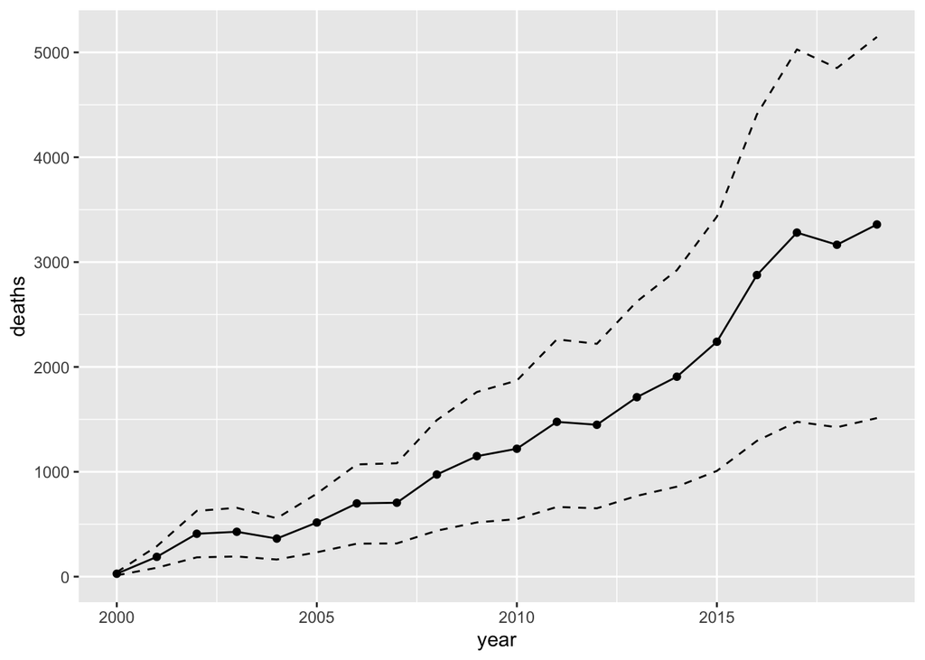

```r
ggplot(yearly_num_Attr_Deaths_redefine_int, aes(x = year, y = deaths)) +
  geom_line() +
  geom_line(aes(y = death_lb, x = year), linetype = "dashed") +
  geom_line(aes(y = death_ub, x = year), linetype = "dashed") +
  geom_point()
```

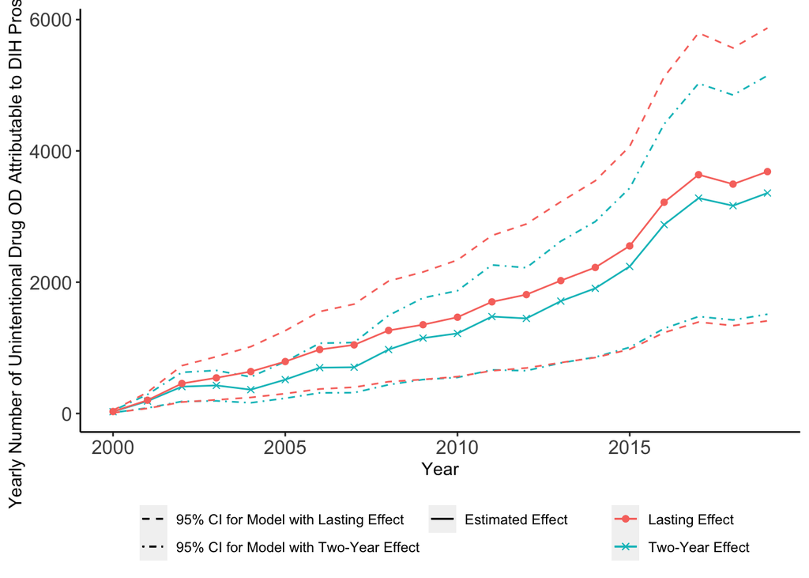

```r
# pdf("./Figures/attributable_deaths_main_analysis_and_secondary.pdf")
ggplot() +
  geom_line(yearly_num_Attr_Deaths_redefine_int, mapping = aes(x = year, y = deaths,
                                                               linetype = "Estimated Effect",
                                                               color = "Two-Year Effect")) +
  geom_point(yearly_num_Attr_Deaths_redefine_int, mapping = aes(y = deaths, x = year,
                                                                shape = "Two-Year Effect",
                                                                color = "Two-Year Effect")) +
  geom_line(yearly_num_Attr_Deaths_redefine_int, mapping = aes(y = death_lb, x = year,
                                                               linetype = "95% CI for Model with Two-Year Effect",
                                                               color = "Two-Year Effect")) +
  geom_line(yearly_num_Attr_Deaths_redefine_int, mapping = aes(y = death_ub, x = year,
                                                               linetype = "95% CI for Model with Two-Year Effect",
                                                               color = "Two-Year Effect")) +
  geom_line(yearly_num_Attr_Deaths_main_analysis, mapping = aes(x = year, y = deaths,
                                                                linetype = "Estimated Effect",
                                                                color = "Lasting Effect")) +
  geom_point(yearly_num_Attr_Deaths_main_analysis,
             mapping = aes(y = deaths, x = year,
                           shape = "Lasting Effect",
                           color = "Lasting Effect")) +
  geom_line(yearly_num_Attr_Deaths_main_analysis, mapping = aes(y = death_lb, x = year,
                                                                color = "Lasting Effect",
                                                                linetype = "95% CI for Model with Lasting Effect")) +
  geom_line(yearly_num_Attr_Deaths_main_analysis, mapping = aes(y = death_ub, x = year,
                                                                color = "Lasting Effect",
                                                                linetype = "95% CI for Model with Lasting Effect")) +
  theme(panel.background = element_rect("white"),
        panel.border = element_blank(),
        panel.grid.major = element_blank(),
        panel.grid.minor = element_blank(),
        axis.line = element_line(colour = "black"),
        axis.text = element_text(size = 12))+
  labs(y = "Yearly Number of Unintentional Drug OD Attributable to DIH Prosecutions",
       x = "Year",
       linetype = "",
       shape = "",
       color = "")+
  theme(legend.position = "bottom") +
  scale_linetype_manual(values = c("dashed", "dotdash", "solid")) +
  guides(color=guide_legend(nrow=2),
         shape=guide_legend(nrow=2),
         linetype = guide_legend(nrow = 2))+
  scale_shape_manual(values = c(19, 4, 17, 5))
```

```r
# dev.off()
```

# 4 GAM with Linear Link